# Risk Factor Analysis

## Outcome Variable

**Outcome Variable:** ever_co

## Predictor Variables

**Intervention Variable:** mage

**Adjustment Set:**

- arm
- meducyrs
- feducyrs
- W_mhtcm
- W_mwtkg
- W_mbmi
- single
- delta_meducyrs
- delta_feducyrs
- delta_W_mhtcm
- delta_W_mwtkg
- delta_W_mbmi
- delta_single

## Stratifying Variables

The analysis was stratified on these variable(s):

- agecat
- studyid
- country

## Data Summary

| agecat | studyid | country | mage | ever_co | n_cell | n |
| --- | --- | --- | --- | --- | --- | --- |
| 0-24 months | ki0047075b-MAL-ED | BANGLADESH | [20-30) | 0 | 161 | 263 |
| 0-24 months | ki0047075b-MAL-ED | BANGLADESH | [20-30) | 1 | 19 | 263 |
| 0-24 months | ki0047075b-MAL-ED | BANGLADESH | <20 | 0 | 27 | 263 |
| 0-24 months | ki0047075b-MAL-ED | BANGLADESH | <20 | 1 | 10 | 263 |
| 0-24 months | ki0047075b-MAL-ED | BANGLADESH | >=30 | 0 | 36 | 263 |
| 0-24 months | ki0047075b-MAL-ED | BANGLADESH | >=30 | 1 | 10 | 263 |
| 0-24 months | ki0047075b-MAL-ED | BRAZIL | [20-30) | 0 | 138 | 233 |
| 0-24 months | ki0047075b-MAL-ED | BRAZIL | [20-30) | 1 | 1 | 233 |
| 0-24 months | ki0047075b-MAL-ED | BRAZIL | <20 | 0 | 43 | 233 |
| 0-24 months | ki0047075b-MAL-ED | BRAZIL | <20 | 1 | 0 | 233 |
| 0-24 months | ki0047075b-MAL-ED | BRAZIL | >=30 | 0 | 49 | 233 |
| 0-24 months | ki0047075b-MAL-ED | BRAZIL | >=30 | 1 | 2 | 233 |
| 0-24 months | ki0047075b-MAL-ED | INDIA | [20-30) | 0 | 152 | 249 |
| 0-24 months | ki0047075b-MAL-ED | INDIA | [20-30) | 1 | 42 | 249 |
| 0-24 months | ki0047075b-MAL-ED | INDIA | <20 | 0 | 23 | 249 |
| 0-24 months | ki0047075b-MAL-ED | INDIA | <20 | 1 | 11 | 249 |
| 0-24 months | ki0047075b-MAL-ED | INDIA | >=30 | 0 | 21 | 249 |
| 0-24 months | ki0047075b-MAL-ED | INDIA | >=30 | 1 | 0 | 249 |
| 0-24 months | ki0047075b-MAL-ED | NEPAL | [20-30) | 0 | 173 | 240 |
| 0-24 months | ki0047075b-MAL-ED | NEPAL | [20-30) | 1 | 16 | 240 |
| 0-24 months | ki0047075b-MAL-ED | NEPAL | <20 | 0 | 3 | 240 |
| 0-24 months | ki0047075b-MAL-ED | NEPAL | <20 | 1 | 2 | 240 |
| 0-24 months | ki0047075b-MAL-ED | NEPAL | >=30 | 0 | 42 | 240 |
| 0-24 months | ki0047075b-MAL-ED | NEPAL | >=30 | 1 | 4 | 240 |
| 0-24 months | ki0047075b-MAL-ED | PERU | [20-30) | 0 | 149 | 302 |
| 0-24 months | ki0047075b-MAL-ED | PERU | [20-30) | 1 | 4 | 302 |
| 0-24 months | ki0047075b-MAL-ED | PERU | <20 | 0 | 77 | 302 |
| 0-24 months | ki0047075b-MAL-ED | PERU | <20 | 1 | 5 | 302 |
| 0-24 months | ki0047075b-MAL-ED | PERU | >=30 | 0 | 64 | 302 |
| 0-24 months | ki0047075b-MAL-ED | PERU | >=30 | 1 | 3 | 302 |

[output cut: 450 more lines]

The following strata were considered:

- agecat: 0-24 months, studyid: ki0047075b-MAL-ED, country: BANGLADESH
- agecat: 0-24 months, studyid: ki0047075b-MAL-ED, country: BRAZIL
- agecat: 0-24 months, studyid: ki0047075b-MAL-ED, country: INDIA
- agecat: 0-24 months, studyid: ki0047075b-MAL-ED, country: NEPAL
- agecat: 0-24 months, studyid: ki0047075b-MAL-ED, country: PERU
- agecat: 0-24 months, studyid: ki0047075b-MAL-ED, country: SOUTH AFRICA
- agecat: 0-24 months, studyid: ki0047075b-MAL-ED, country: TANZANIA, UNITED REPUBLIC OF
- agecat: 0-24 months, studyid: ki1000108-CMC-V-BCS-2002, country: INDIA
- agecat: 0-24 months, studyid: ki1000108-IRC, country: INDIA
- agecat: 0-24 months, studyid: ki1000109-EE, country: PAKISTAN
- agecat: 0-24 months, studyid: ki1000304b-SAS-CompFeed, country: INDIA
- agecat: 0-24 months, studyid: ki1000304b-SAS-FoodSuppl, country: INDIA
- agecat: 0-24 months, studyid: ki1017093-NIH-Birth, country: BANGLADESH
- agecat: 0-24 months, studyid: ki1017093b-PROVIDE, country: BANGLADESH
- agecat: 0-24 months, studyid: ki1017093c-NIH-Crypto, country: BANGLADESH
- agecat: 0-24 months, studyid: ki1066203-TanzaniaChild2, country: TANZANIA, UNITED REPUBLIC OF
- agecat: 0-24 months, studyid: ki1101329-Keneba, country: GAMBIA
- agecat: 0-24 months, studyid: ki1112895-Guatemala BSC, country: GUATEMALA
- agecat: 0-24 months, studyid: ki1112895-iLiNS-Zinc, country: BURKINA FASO
- agecat: 0-24 months, studyid: ki1113344-GMS-Nepal, country: NEPAL
- agecat: 0-24 months, studyid: ki1119695-PROBIT, country: BELARUS
- agecat: 0-24 months, studyid: ki1126311-ZVITAMBO, country: ZIMBABWE
- agecat: 0-24 months, studyid: ki1135781-COHORTS, country: GUATEMALA
- agecat: 0-24 months, studyid: ki1135781-COHORTS, country: INDIA
- agecat: 0-24 months, studyid: ki1135781-COHORTS, country: PHILIPPINES
- agecat: 0-24 months, studyid: ki1148112-LCNI-5, country: MALAWI
- agecat: 0-24 months, studyid: kiGH5241-JiVitA-3, country: BANGLADESH
- agecat: 0-6 months, studyid: ki0047075b-MAL-ED, country: BANGLADESH
- agecat: 0-6 months, studyid: ki0047075b-MAL-ED, country: BRAZIL
- agecat: 0-6 months, studyid: ki0047075b-MAL-ED, country: INDIA
- agecat: 0-6 months, studyid: ki0047075b-MAL-ED, country: NEPAL
- agecat: 0-6 months, studyid: ki0047075b-MAL-ED, country: PERU
- agecat: 0-6 months, studyid: ki0047075b-MAL-ED, country: SOUTH AFRICA
- agecat: 0-6 months, studyid: ki0047075b-MAL-ED, country: TANZANIA, UNITED REPUBLIC OF
- agecat: 0-6 months, studyid: ki1000108-CMC-V-BCS-2002, country: INDIA
- agecat: 0-6 months, studyid: ki1000108-IRC, country: INDIA
- agecat: 0-6 months, studyid: ki1000109-EE, country: PAKISTAN
- agecat: 0-6 months, studyid: ki1000304b-SAS-CompFeed, country: INDIA
- agecat: 0-6 months, studyid: ki1000304b-SAS-FoodSuppl, country: INDIA
- agecat: 0-6 months, studyid: ki1017093-NIH-Birth, country: BANGLADESH
- agecat: 0-6 months, studyid: ki1017093b-PROVIDE, country: BANGLADESH
- agecat: 0-6 months, studyid: ki1017093c-NIH-Crypto, country: BANGLADESH
- agecat: 0-6 months, studyid: ki1066203-TanzaniaChild2, country: TANZANIA, UNITED REPUBLIC OF
- agecat: 0-6 months, studyid: ki1101329-Keneba, country: GAMBIA
- agecat: 0-6 months, studyid: ki1112895-Guatemala BSC, country: GUATEMALA
- agecat: 0-6 months, studyid: ki1113344-GMS-Nepal, country: NEPAL
- agecat: 0-6 months, studyid: ki1119695-PROBIT, country: BELARUS
- agecat: 0-6 months, studyid: ki1126311-ZVITAMBO, country: ZIMBABWE
- agecat: 0-6 months, studyid: ki1135781-COHORTS, country: GUATEMALA
- agecat: 0-6 months, studyid: ki1135781-COHORTS, country: INDIA
- agecat: 0-6 months, studyid: ki1135781-COHORTS, country: PHILIPPINES
- agecat: 0-6 months, studyid: ki1148112-LCNI-5, country: MALAWI
- agecat: 0-6 months, studyid: kiGH5241-JiVitA-3, country: BANGLADESH
- agecat: 6-24 months, studyid: ki0047075b-MAL-ED, country: BANGLADESH
- agecat: 6-24 months, studyid: ki0047075b-MAL-ED, country: BRAZIL
- agecat: 6-24 months, studyid: ki0047075b-MAL-ED, country: INDIA
- agecat: 6-24 months, studyid: ki0047075b-MAL-ED, country: NEPAL
- agecat: 6-24 months, studyid: ki0047075b-MAL-ED, country: PERU
- agecat: 6-24 months, studyid: ki0047075b-MAL-ED, country: SOUTH AFRICA
- agecat: 6-24 months, studyid: ki0047075b-MAL-ED, country: TANZANIA, UNITED REPUBLIC OF
- agecat: 6-24 months, studyid: ki1000108-CMC-V-BCS-2002, country: INDIA
- agecat: 6-24 months, studyid: ki1000108-IRC, country: INDIA
- agecat: 6-24 months, studyid: ki1000109-EE, country: PAKISTAN
- agecat: 6-24 months, studyid: ki1000304b-SAS-CompFeed, country: INDIA
- agecat: 6-24 months, studyid: ki1000304b-SAS-FoodSuppl, country: INDIA
- agecat: 6-24 months, studyid: ki1017093-NIH-Birth, country: BANGLADESH
- agecat: 6-24 months, studyid: ki1017093b-PROVIDE, country: BANGLADESH
- agecat: 6-24 months, studyid: ki1017093c-NIH-Crypto, country: BANGLADESH
- agecat: 6-24 months, studyid: ki1066203-TanzaniaChild2, country: TANZANIA, UNITED REPUBLIC OF
- agecat: 6-24 months, studyid: ki1101329-Keneba, country: GAMBIA
- agecat: 6-24 months, studyid: ki1112895-Guatemala BSC, country: GUATEMALA
- agecat: 6-24 months, studyid: ki1112895-iLiNS-Zinc, country: BURKINA FASO
- agecat: 6-24 months, studyid: ki1113344-GMS-Nepal, country: NEPAL
- agecat: 6-24 months, studyid: ki1119695-PROBIT, country: BELARUS
- agecat: 6-24 months, studyid: ki1126311-ZVITAMBO, country: ZIMBABWE
- agecat: 6-24 months, studyid: ki1135781-COHORTS, country: GUATEMALA
- agecat: 6-24 months, studyid: ki1135781-COHORTS, country: INDIA
- agecat: 6-24 months, studyid: ki1135781-COHORTS, country: PHILIPPINES
- agecat: 6-24 months, studyid: ki1148112-LCNI-5, country: MALAWI
- agecat: 6-24 months, studyid: kiGH5241-JiVitA-3, country: BANGLADESH

### Dropped Strata

Some strata were dropped due to rare outcomes:

- agecat: 0-24 months, studyid: ki0047075b-MAL-ED, country: BRAZIL
- agecat: 0-24 months, studyid: ki0047075b-MAL-ED, country: INDIA
- agecat: 0-24 months, studyid: ki0047075b-MAL-ED, country: NEPAL
- agecat: 0-24 months, studyid: ki0047075b-MAL-ED, country: PERU
- agecat: 0-24 months, studyid: ki0047075b-MAL-ED, country: SOUTH AFRICA
- agecat: 0-24 months, studyid: ki0047075b-MAL-ED, country: TANZANIA, UNITED REPUBLIC OF
- agecat: 0-24 months, studyid: ki1000109-EE, country: PAKISTAN
- agecat: 0-24 months, studyid: ki1119695-PROBIT, country: BELARUS
- agecat: 0-6 months, studyid: ki0047075b-MAL-ED, country: BANGLADESH
- agecat: 0-6 months, studyid: ki0047075b-MAL-ED, country: BRAZIL
- agecat: 0-6 months, studyid: ki0047075b-MAL-ED, country: INDIA
- agecat: 0-6 months, studyid: ki0047075b-MAL-ED, country: NEPAL
- agecat: 0-6 months, studyid: ki0047075b-MAL-ED, country: PERU
- agecat: 0-6 months, studyid: ki0047075b-MAL-ED, country: SOUTH AFRICA
- agecat: 0-6 months, studyid: ki0047075b-MAL-ED, country: TANZANIA, UNITED REPUBLIC OF
- agecat: 0-6 months, studyid: ki1000108-CMC-V-BCS-2002, country: INDIA
- agecat: 0-6 months, studyid: ki1000108-IRC, country: INDIA
- agecat: 0-6 months, studyid: ki1000109-EE, country: PAKISTAN
- agecat: 0-6 months, studyid: ki1000304b-SAS-FoodSuppl, country: INDIA
- agecat: 0-6 months, studyid: ki1017093-NIH-Birth, country: BANGLADESH
- agecat: 0-6 months, studyid: ki1017093b-PROVIDE, country: BANGLADESH
- agecat: 0-6 months, studyid: ki1017093c-NIH-Crypto, country: BANGLADESH
- agecat: 0-6 months, studyid: ki1066203-TanzaniaChild2, country: TANZANIA, UNITED REPUBLIC OF
- agecat: 0-6 months, studyid: ki1112895-Guatemala BSC, country: GUATEMALA
- agecat: 0-6 months, studyid: ki1119695-PROBIT, country: BELARUS
- agecat: 0-6 months, studyid: ki1135781-COHORTS, country: GUATEMALA
- agecat: 0-6 months, studyid: ki1148112-LCNI-5, country: MALAWI
- agecat: 6-24 months, studyid: ki0047075b-MAL-ED, country: BRAZIL
- agecat: 6-24 months, studyid: ki0047075b-MAL-ED, country: INDIA
- agecat: 6-24 months, studyid: ki0047075b-MAL-ED, country: NEPAL
- agecat: 6-24 months, studyid: ki0047075b-MAL-ED, country: PERU
- agecat: 6-24 months, studyid: ki0047075b-MAL-ED, country: SOUTH AFRICA
- agecat: 6-24 months, studyid: ki0047075b-MAL-ED, country: TANZANIA, UNITED REPUBLIC OF
- agecat: 6-24 months, studyid: ki1000109-EE, country: PAKISTAN
- agecat: 6-24 months, studyid: ki1112895-Guatemala BSC, country: GUATEMALA
- agecat: 6-24 months, studyid: ki1119695-PROBIT, country: BELARUS

## Methods Detail

We’re interested in the causal parameters $E[Y_a]$ for all values of $a \in \mathcal{A}$. These parameters represent the mean outcome if, possibly contrary to fact, we intervened to set all units to have $A=a$. Under the randomization and positivity assumptions, these are identified by the statistical parameters $\psi_a=E_W[E_{Y|A,W}(Y|A=a,W)]$. In addition, we’re interested in the mean of $Y$, $E[Y]$ under no intervention (the observed mean). We will estimate these parameters by using SuperLearner to fit the relevant likelihood factors – $E_{Y|A,W}(Y|A=a,W)$ and $p(A=a|W)$, and then updating our likelihood fit using a joint TMLE.

For unadjusted analyses ($W=\{\}$), initial likelihoods were estimated using Lrnr_glm to estimate the simple $E(Y|A)$ and Lrnr_mean to estimate $p(A)$. For adjusted analyses, a small library containing Lrnr_glmnet, Lrnr_xgboost, and Lrnr_mean was used.

Having estimated these parameters, we will then use the delta method to estimate relative risks and attributable risks relative to a prespecified baseline level of $A$.

# Results Detail

## Results Plots

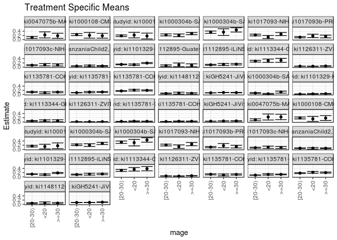

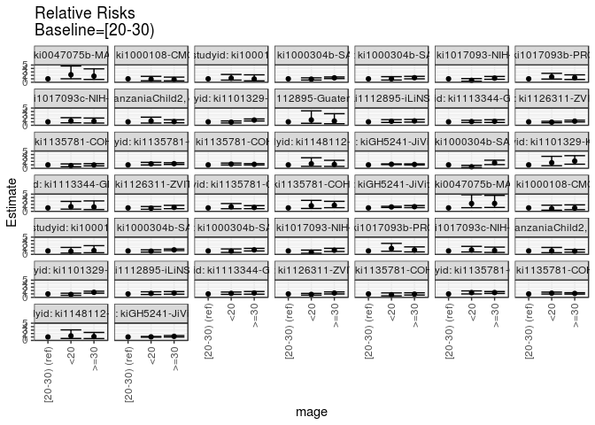

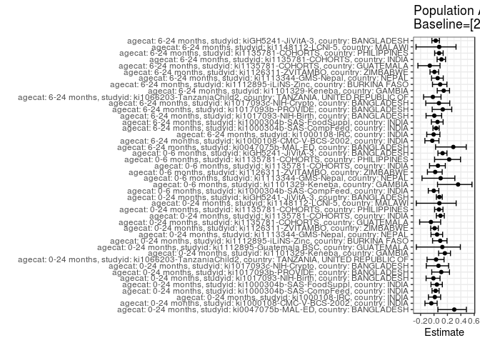

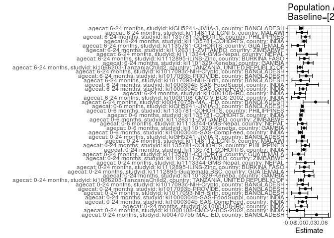

## Results Table

### Parameter: TSM

| agecat | studyid | country | intervention_level | baseline_level | estimate | ci_lower | ci_upper |
| --- | --- | --- | --- | --- | --- | --- | --- |
| 0-24 months | ki0047075b-MAL-ED | BANGLADESH | [20-30) | NA | 0.1034867 | 0.0586785 | 0.1482949 |
| 0-24 months | ki0047075b-MAL-ED | BANGLADESH | <20 | NA | 0.2259795 | 0.0808133 | 0.3711458 |
| 0-24 months | ki0047075b-MAL-ED | BANGLADESH | >=30 | NA | 0.1837610 | 0.0624434 | 0.3050786 |
| 0-24 months | ki1000108-CMC-V-BCS-2002 | INDIA | [20-30) | NA | 0.2398649 | 0.1911553 | 0.2885744 |
| 0-24 months | ki1000108-CMC-V-BCS-2002 | INDIA | <20 | NA | 0.2058824 | 0.0697869 | 0.3419778 |
| 0-24 months | ki1000108-CMC-V-BCS-2002 | INDIA | >=30 | NA | 0.1860465 | 0.0695783 | 0.3025147 |
| 0-24 months | ki1000108-IRC | INDIA | [20-30) | NA | 0.1831395 | 0.1422168 | 0.2240622 |
| 0-24 months | ki1000108-IRC | INDIA | <20 | NA | 0.2162162 | 0.0834096 | 0.3490229 |
| 0-24 months | ki1000108-IRC | INDIA | >=30 | NA | 0.1724138 | 0.0347651 | 0.3100625 |
| 0-24 months | ki1000304b-SAS-CompFeed | INDIA | [20-30) | NA | 0.2263417 | 0.1790800 | 0.2736034 |
| 0-24 months | ki1000304b-SAS-CompFeed | INDIA | <20 | NA | 0.2051052 | 0.1415719 | 0.2686384 |
| 0-24 months | ki1000304b-SAS-CompFeed | INDIA | >=30 | NA | 0.2891216 | 0.2366249 | 0.3416183 |
| 0-24 months | ki1000304b-SAS-FoodSuppl | INDIA | [20-30) | NA | 0.3548474 | 0.2997216 | 0.4099732 |
| 0-24 months | ki1000304b-SAS-FoodSuppl | INDIA | <20 | NA | 0.3601054 | 0.2011609 | 0.5190499 |
| 0-24 months | ki1000304b-SAS-FoodSuppl | INDIA | >=30 | NA | 0.4638013 | 0.3612919 | 0.5663107 |
| 0-24 months | ki1017093-NIH-Birth | BANGLADESH | [20-30) | NA | 0.2206235 | 0.1807918 | 0.2604552 |
| 0-24 months | ki1017093-NIH-Birth | BANGLADESH | <20 | NA | 0.1232877 | 0.0478090 | 0.1987664 |
| 0-24 months | ki1017093-NIH-Birth | BANGLADESH | >=30 | NA | 0.2651515 | 0.1897888 | 0.3405142 |
| 0-24 months | ki1017093b-PROVIDE | BANGLADESH | [20-30) | NA | 0.1146465 | 0.0866455 | 0.1426475 |
| 0-24 months | ki1017093b-PROVIDE | BANGLADESH | <20 | NA | 0.1768238 | 0.0956208 | 0.2580268 |
| 0-24 months | ki1017093b-PROVIDE | BANGLADESH | >=30 | NA | 0.1508291 | 0.0853012 | 0.2163571 |
| 0-24 months | ki1017093c-NIH-Crypto | BANGLADESH | [20-30) | NA | 0.0874506 | 0.0625200 | 0.1123813 |
| 0-24 months | ki1017093c-NIH-Crypto | BANGLADESH | <20 | NA | 0.1102895 | 0.0574919 | 0.1630871 |
| 0-24 months | ki1017093c-NIH-Crypto | BANGLADESH | >=30 | NA | 0.1022189 | 0.0498726 | 0.1545652 |
| 0-24 months | ki1066203-TanzaniaChild2 | TANZANIA, UNITED REPUBLIC OF | [20-30) | NA | 0.0485335 | 0.0378644 | 0.0592026 |
| 0-24 months | ki1066203-TanzaniaChild2 | TANZANIA, UNITED REPUBLIC OF | <20 | NA | 0.0600673 | 0.0237568 | 0.0963778 |
| 0-24 months | ki1066203-TanzaniaChild2 | TANZANIA, UNITED REPUBLIC OF | >=30 | NA | 0.0519835 | 0.0347461 | 0.0692208 |
| 0-24 months | ki1101329-Keneba | GAMBIA | [20-30) | NA | 0.1258827 | 0.1083764 | 0.1433891 |
| 0-24 months | ki1101329-Keneba | GAMBIA | <20 | NA | 0.1149734 | 0.0817211 | 0.1482256 |
| 0-24 months | ki1101329-Keneba | GAMBIA | >=30 | NA | 0.1911293 | 0.1670640 | 0.2151947 |

[output cut: 102 more lines]

### Parameter: E(Y)

| agecat | studyid | country | intervention_level | baseline_level | estimate | ci_lower | ci_upper |
| --- | --- | --- | --- | --- | --- | --- | --- |
| 0-24 months | ki0047075b-MAL-ED | BANGLADESH | NA | NA | 0.1482890 | 0.1052563 | 0.1913216 |
| 0-24 months | ki1000108-CMC-V-BCS-2002 | INDIA | NA | NA | 0.2305630 | 0.1877616 | 0.2733644 |
| 0-24 months | ki1000108-IRC | INDIA | NA | NA | 0.1853659 | 0.1477057 | 0.2230261 |
| 0-24 months | ki1000304b-SAS-CompFeed | INDIA | NA | NA | 0.2319894 | 0.1917264 | 0.2722524 |
| 0-24 months | ki1000304b-SAS-FoodSuppl | INDIA | NA | NA | 0.3708134 | 0.3244530 | 0.4171738 |
| 0-24 months | ki1017093-NIH-Birth | BANGLADESH | NA | NA | 0.2186495 | 0.1861408 | 0.2511582 |
| 0-24 months | ki1017093b-PROVIDE | BANGLADESH | NA | NA | 0.1285714 | 0.1037574 | 0.1533855 |
| 0-24 months | ki1017093c-NIH-Crypto | BANGLADESH | NA | NA | 0.0936675 | 0.0729118 | 0.1144233 |
| 0-24 months | ki1066203-TanzaniaChild2 | TANZANIA, UNITED REPUBLIC OF | NA | NA | 0.0500842 | 0.0413120 | 0.0588564 |
| 0-24 months | ki1101329-Keneba | GAMBIA | NA | NA | 0.1501575 | 0.1370563 | 0.1632587 |
| 0-24 months | ki1112895-Guatemala BSC | GUATEMALA | NA | NA | 0.0782918 | 0.0468271 | 0.1097565 |
| 0-24 months | ki1112895-iLiNS-Zinc | BURKINA FASO | NA | NA | 0.1195721 | 0.0998202 | 0.1393239 |
| 0-24 months | ki1113344-GMS-Nepal | NEPAL | NA | NA | 0.2944606 | 0.2603274 | 0.3285938 |
| 0-24 months | ki1126311-ZVITAMBO | ZIMBABWE | NA | NA | 0.0424338 | 0.0390831 | 0.0457845 |
| 0-24 months | ki1135781-COHORTS | GUATEMALA | NA | NA | 0.1103654 | 0.0935883 | 0.1271425 |
| 0-24 months | ki1135781-COHORTS | INDIA | NA | NA | 0.0980577 | 0.0900528 | 0.1060627 |
| 0-24 months | ki1135781-COHORTS | PHILIPPINES | NA | NA | 0.1839080 | 0.1701456 | 0.1976705 |
| 0-24 months | ki1148112-LCNI-5 | MALAWI | NA | NA | 0.0537313 | 0.0366447 | 0.0708180 |
| 0-24 months | kiGH5241-JiVitA-3 | BANGLADESH | NA | NA | 0.0888451 | 0.0849346 | 0.0927557 |
| 0-6 months | ki1000304b-SAS-CompFeed | INDIA | NA | NA | 0.0704787 | 0.0478990 | 0.0930584 |
| 0-6 months | ki1101329-Keneba | GAMBIA | NA | NA | 0.0282787 | 0.0216999 | 0.0348574 |
| 0-6 months | ki1113344-GMS-Nepal | NEPAL | NA | NA | 0.0524781 | 0.0357793 | 0.0691770 |
| 0-6 months | ki1126311-ZVITAMBO | ZIMBABWE | NA | NA | 0.0120944 | 0.0102712 | 0.0139177 |
| 0-6 months | ki1135781-COHORTS | INDIA | NA | NA | 0.0274456 | 0.0229617 | 0.0319295 |
| 0-6 months | ki1135781-COHORTS | PHILIPPINES | NA | NA | 0.0236531 | 0.0182537 | 0.0290525 |
| 0-6 months | kiGH5241-JiVitA-3 | BANGLADESH | NA | NA | 0.0396941 | 0.0371916 | 0.0421966 |
| 6-24 months | ki0047075b-MAL-ED | BANGLADESH | NA | NA | 0.1464435 | 0.1015265 | 0.1913605 |
| 6-24 months | ki1000108-CMC-V-BCS-2002 | INDIA | NA | NA | 0.1876676 | 0.1479906 | 0.2273445 |
| 6-24 months | ki1000108-IRC | INDIA | NA | NA | 0.1560976 | 0.1209228 | 0.1912723 |
| 6-24 months | ki1000304b-SAS-CompFeed | INDIA | NA | NA | 0.2260619 | 0.1909133 | 0.2612105 |
| 6-24 months | ki1000304b-SAS-FoodSuppl | INDIA | NA | NA | 0.3615960 | 0.3145115 | 0.4086805 |
| 6-24 months | ki1017093-NIH-Birth | BANGLADESH | NA | NA | 0.2092593 | 0.1749182 | 0.2436003 |
| 6-24 months | ki1017093b-PROVIDE | BANGLADESH | NA | NA | 0.1221498 | 0.0962275 | 0.1480722 |
| 6-24 months | ki1017093c-NIH-Crypto | BANGLADESH | NA | NA | 0.0863014 | 0.0659171 | 0.1066856 |
| 6-24 months | ki1066203-TanzaniaChild2 | TANZANIA, UNITED REPUBLIC OF | NA | NA | 0.0564436 | 0.0463321 | 0.0665551 |
| 6-24 months | ki1101329-Keneba | GAMBIA | NA | NA | 0.1489203 | 0.1354543 | 0.1623863 |
| 6-24 months | ki1112895-iLiNS-Zinc | BURKINA FASO | NA | NA | 0.1195721 | 0.0998202 | 0.1393239 |
| 6-24 months | ki1113344-GMS-Nepal | NEPAL | NA | NA | 0.3254237 | 0.2875855 | 0.3632619 |
| 6-24 months | ki1126311-ZVITAMBO | ZIMBABWE | NA | NA | 0.0410680 | 0.0373229 | 0.0448131 |
| 6-24 months | ki1135781-COHORTS | GUATEMALA | NA | NA | 0.1123039 | 0.0945135 | 0.1300943 |
| 6-24 months | ki1135781-COHORTS | INDIA | NA | NA | 0.0928355 | 0.0847544 | 0.1009166 |
| 6-24 months | ki1135781-COHORTS | PHILIPPINES | NA | NA | 0.1908832 | 0.1763448 | 0.2054216 |
| 6-24 months | ki1148112-LCNI-5 | MALAWI | NA | NA | 0.0546282 | 0.0372644 | 0.0719920 |
| 6-24 months | kiGH5241-JiVitA-3 | BANGLADESH | NA | NA | 0.0868936 | 0.0822329 | 0.0915543 |

### Parameter: RR

| agecat | studyid | country | intervention_level | baseline_level | estimate | ci_lower | ci_upper |
| --- | --- | --- | --- | --- | --- | --- | --- |
| 0-24 months | ki0047075b-MAL-ED | BANGLADESH | [20-30) | [20-30) | 1.0000000 | 1.0000000 | 1.0000000 |
| 0-24 months | ki0047075b-MAL-ED | BANGLADESH | <20 | [20-30) | 2.1836579 | 1.0102320 | 4.7200660 |
| 0-24 months | ki0047075b-MAL-ED | BANGLADESH | >=30 | [20-30) | 1.7756967 | 0.8111635 | 3.8871310 |
| 0-24 months | ki1000108-CMC-V-BCS-2002 | INDIA | [20-30) | [20-30) | 1.0000000 | 1.0000000 | 1.0000000 |
| 0-24 months | ki1000108-CMC-V-BCS-2002 | INDIA | <20 | [20-30) | 0.8583264 | 0.4298605 | 1.7138681 |
| 0-24 months | ki1000108-CMC-V-BCS-2002 | INDIA | >=30 | [20-30) | 0.7756305 | 0.4016362 | 1.4978796 |
| 0-24 months | ki1000108-IRC | INDIA | [20-30) | [20-30) | 1.0000000 | 1.0000000 | 1.0000000 |
| 0-24 months | ki1000108-IRC | INDIA | <20 | [20-30) | 1.1806092 | 0.6141094 | 2.2696901 |
| 0-24 months | ki1000108-IRC | INDIA | >=30 | [20-30) | 0.9414340 | 0.4109046 | 2.1569435 |
| 0-24 months | ki1000304b-SAS-CompFeed | INDIA | [20-30) | [20-30) | 1.0000000 | 1.0000000 | 1.0000000 |
| 0-24 months | ki1000304b-SAS-CompFeed | INDIA | <20 | [20-30) | 0.9061749 | 0.6395193 | 1.2840158 |
| 0-24 months | ki1000304b-SAS-CompFeed | INDIA | >=30 | [20-30) | 1.2773677 | 1.0617883 | 1.5367170 |
| 0-24 months | ki1000304b-SAS-FoodSuppl | INDIA | [20-30) | [20-30) | 1.0000000 | 1.0000000 | 1.0000000 |
| 0-24 months | ki1000304b-SAS-FoodSuppl | INDIA | <20 | [20-30) | 1.0148176 | 0.6354622 | 1.6206388 |
| 0-24 months | ki1000304b-SAS-FoodSuppl | INDIA | >=30 | [20-30) | 1.3070443 | 0.9972178 | 1.7131312 |
| 0-24 months | ki1017093-NIH-Birth | BANGLADESH | [20-30) | [20-30) | 1.0000000 | 1.0000000 | 1.0000000 |
| 0-24 months | ki1017093-NIH-Birth | BANGLADESH | <20 | [20-30) | 0.5588148 | 0.2951655 | 1.0579624 |
| 0-24 months | ki1017093-NIH-Birth | BANGLADESH | >=30 | [20-30) | 1.2018281 | 0.8582375 | 1.6829732 |
| 0-24 months | ki1017093b-PROVIDE | BANGLADESH | [20-30) | [20-30) | 1.0000000 | 1.0000000 | 1.0000000 |
| 0-24 months | ki1017093b-PROVIDE | BANGLADESH | <20 | [20-30) | 1.5423391 | 0.9174904 | 2.5927355 |
| 0-24 months | ki1017093b-PROVIDE | BANGLADESH | >=30 | [20-30) | 1.3156019 | 0.7997407 | 2.1642119 |
| 0-24 months | ki1017093c-NIH-Crypto | BANGLADESH | [20-30) | [20-30) | 1.0000000 | 1.0000000 | 1.0000000 |
| 0-24 months | ki1017093c-NIH-Crypto | BANGLADESH | <20 | [20-30) | 1.2611630 | 0.7228113 | 2.2004802 |
| 0-24 months | ki1017093c-NIH-Crypto | BANGLADESH | >=30 | [20-30) | 1.1688751 | 0.6503028 | 2.1009737 |
| 0-24 months | ki1066203-TanzaniaChild2 | TANZANIA, UNITED REPUBLIC OF | [20-30) | [20-30) | 1.0000000 | 1.0000000 | 1.0000000 |
| 0-24 months | ki1066203-TanzaniaChild2 | TANZANIA, UNITED REPUBLIC OF | <20 | [20-30) | 1.2376461 | 0.6505628 | 2.3545272 |
| 0-24 months | ki1066203-TanzaniaChild2 | TANZANIA, UNITED REPUBLIC OF | >=30 | [20-30) | 1.0710845 | 0.7195891 | 1.5942738 |
| 0-24 months | ki1101329-Keneba | GAMBIA | [20-30) | [20-30) | 1.0000000 | 1.0000000 | 1.0000000 |
| 0-24 months | ki1101329-Keneba | GAMBIA | <20 | [20-30) | 0.9133370 | 0.6629841 | 1.2582271 |
| 0-24 months | ki1101329-Keneba | GAMBIA | >=30 | [20-30) | 1.5183122 | 1.2594498 | 1.8303803 |

[output cut: 102 more lines]

### Parameter: PAR

| agecat | studyid | country | intervention_level | baseline_level | estimate | ci_lower | ci_upper |
| --- | --- | --- | --- | --- | --- | --- | --- |
| 0-24 months | ki0047075b-MAL-ED | BANGLADESH | [20-30) | NA | 0.0448023 | 0.0120172 | 0.0775874 |
| 0-24 months | ki1000108-CMC-V-BCS-2002 | INDIA | [20-30) | NA | -0.0093019 | -0.0302523 | 0.0116486 |
| 0-24 months | ki1000108-IRC | INDIA | [20-30) | NA | 0.0022263 | -0.0145899 | 0.0190425 |
| 0-24 months | ki1000304b-SAS-CompFeed | INDIA | [20-30) | NA | 0.0056477 | -0.0060757 | 0.0173712 |
| 0-24 months | ki1000304b-SAS-FoodSuppl | INDIA | [20-30) | NA | 0.0159660 | -0.0153262 | 0.0472582 |
| 0-24 months | ki1017093-NIH-Birth | BANGLADESH | [20-30) | NA | -0.0019740 | -0.0246909 | 0.0207429 |
| 0-24 months | ki1017093b-PROVIDE | BANGLADESH | [20-30) | NA | 0.0139249 | -0.0032197 | 0.0310695 |
| 0-24 months | ki1017093c-NIH-Crypto | BANGLADESH | [20-30) | NA | 0.0062169 | -0.0093961 | 0.0218299 |
| 0-24 months | ki1066203-TanzaniaChild2 | TANZANIA, UNITED REPUBLIC OF | [20-30) | NA | 0.0015507 | -0.0047850 | 0.0078864 |
| 0-24 months | ki1101329-Keneba | GAMBIA | [20-30) | NA | 0.0242748 | 0.0109079 | 0.0376416 |
| 0-24 months | ki1112895-Guatemala BSC | GUATEMALA | [20-30) | NA | 0.0097204 | -0.0156673 | 0.0351081 |
| 0-24 months | ki1112895-iLiNS-Zinc | BURKINA FASO | [20-30) | NA | 0.0110361 | -0.0019312 | 0.0240035 |
| 0-24 months | ki1113344-GMS-Nepal | NEPAL | [20-30) | NA | 0.0134204 | -0.0120841 | 0.0389248 |
| 0-24 months | ki1126311-ZVITAMBO | ZIMBABWE | [20-30) | NA | 0.0003749 | -0.0020249 | 0.0027748 |
| 0-24 months | ki1135781-COHORTS | GUATEMALA | [20-30) | NA | -0.0050649 | -0.0223187 | 0.0121889 |
| 0-24 months | ki1135781-COHORTS | INDIA | [20-30) | NA | 0.0093970 | 0.0035594 | 0.0152346 |
| 0-24 months | ki1135781-COHORTS | PHILIPPINES | [20-30) | NA | 0.0134789 | 0.0020179 | 0.0249399 |
| 0-24 months | ki1148112-LCNI-5 | MALAWI | [20-30) | NA | 0.0042808 | -0.0114972 | 0.0200588 |
| 0-24 months | kiGH5241-JiVitA-3 | BANGLADESH | [20-30) | NA | 0.0071163 | 0.0032029 | 0.0110297 |
| 0-6 months | ki1000304b-SAS-CompFeed | INDIA | [20-30) | NA | -0.0002636 | -0.0057992 | 0.0052719 |
| 0-6 months | ki1101329-Keneba | GAMBIA | [20-30) | NA | 0.0101535 | 0.0027193 | 0.0175876 |
| 0-6 months | ki1113344-GMS-Nepal | NEPAL | [20-30) | NA | 0.0051808 | -0.0076210 | 0.0179826 |
| 0-6 months | ki1126311-ZVITAMBO | ZIMBABWE | [20-30) | NA | 0.0002173 | -0.0011113 | 0.0015459 |
| 0-6 months | ki1135781-COHORTS | INDIA | [20-30) | NA | 0.0016015 | -0.0016269 | 0.0048299 |
| 0-6 months | ki1135781-COHORTS | PHILIPPINES | [20-30) | NA | 0.0053449 | 0.0006557 | 0.0100341 |
| 0-6 months | kiGH5241-JiVitA-3 | BANGLADESH | [20-30) | NA | 0.0050816 | 0.0024039 | 0.0077592 |
| 6-24 months | ki0047075b-MAL-ED | BANGLADESH | [20-30) | NA | 0.0421490 | 0.0073244 | 0.0769737 |
| 6-24 months | ki1000108-CMC-V-BCS-2002 | INDIA | [20-30) | NA | -0.0049000 | -0.0245550 | 0.0147550 |
| 6-24 months | ki1000108-IRC | INDIA | [20-30) | NA | -0.0008792 | -0.0161369 | 0.0143785 |
| 6-24 months | ki1000304b-SAS-CompFeed | INDIA | [20-30) | NA | 0.0071113 | -0.0029636 | 0.0171863 |
| 6-24 months | ki1000304b-SAS-FoodSuppl | INDIA | [20-30) | NA | 0.0189322 | -0.0126643 | 0.0505287 |
| 6-24 months | ki1017093-NIH-Birth | BANGLADESH | [20-30) | NA | 0.0009259 | -0.0233964 | 0.0252482 |
| 6-24 months | ki1017093b-PROVIDE | BANGLADESH | [20-30) | NA | 0.0159891 | -0.0020184 | 0.0339966 |
| 6-24 months | ki1017093c-NIH-Crypto | BANGLADESH | [20-30) | NA | 0.0062872 | -0.0091268 | 0.0217012 |
| 6-24 months | ki1066203-TanzaniaChild2 | TANZANIA, UNITED REPUBLIC OF | [20-30) | NA | -0.0009837 | -0.0083121 | 0.0063447 |
| 6-24 months | ki1101329-Keneba | GAMBIA | [20-30) | NA | 0.0215440 | 0.0078362 | 0.0352518 |
| 6-24 months | ki1112895-iLiNS-Zinc | BURKINA FASO | [20-30) | NA | 0.0108894 | -0.0020079 | 0.0237867 |
| 6-24 months | ki1113344-GMS-Nepal | NEPAL | [20-30) | NA | 0.0177301 | -0.0106429 | 0.0461030 |
| 6-24 months | ki1126311-ZVITAMBO | ZIMBABWE | [20-30) | NA | 0.0002731 | -0.0023757 | 0.0029219 |
| 6-24 months | ki1135781-COHORTS | GUATEMALA | [20-30) | NA | -0.0070622 | -0.0255645 | 0.0114402 |
| 6-24 months | ki1135781-COHORTS | INDIA | [20-30) | NA | 0.0102995 | 0.0044196 | 0.0161794 |
| 6-24 months | ki1135781-COHORTS | PHILIPPINES | [20-30) | NA | 0.0143634 | 0.0022938 | 0.0264330 |
| 6-24 months | ki1148112-LCNI-5 | MALAWI | [20-30) | NA | 0.0042081 | -0.0118680 | 0.0202841 |
| 6-24 months | kiGH5241-JiVitA-3 | BANGLADESH | [20-30) | NA | 0.0022322 | -0.0026255 | 0.0070899 |

### Parameter: PAF

| agecat | studyid | country | intervention_level | baseline_level | estimate | ci_lower | ci_upper |
| --- | --- | --- | --- | --- | --- | --- | --- |
| 0-24 months | ki0047075b-MAL-ED | BANGLADESH | [20-30) | NA | 0.3021282 | 0.0576172 | 0.4831983 |
| 0-24 months | ki1000108-CMC-V-BCS-2002 | INDIA | [20-30) | NA | -0.0403441 | -0.1351701 | 0.0465606 |
| 0-24 months | ki1000108-IRC | INDIA | [20-30) | NA | 0.0120104 | -0.0829843 | 0.0986726 |
| 0-24 months | ki1000304b-SAS-CompFeed | INDIA | [20-30) | NA | 0.0243448 | -0.0298966 | 0.0757294 |
| 0-24 months | ki1000304b-SAS-FoodSuppl | INDIA | [20-30) | NA | 0.0430567 | -0.0451698 | 0.1238357 |
| 0-24 months | ki1017093-NIH-Birth | BANGLADESH | [20-30) | NA | -0.0090281 | -0.1184575 | 0.0896948 |
| 0-24 months | ki1017093b-PROVIDE | BANGLADESH | [20-30) | NA | 0.1083050 | -0.0338395 | 0.2309058 |
| 0-24 months | ki1017093c-NIH-Crypto | BANGLADESH | [20-30) | NA | 0.0663720 | -0.1154557 | 0.2185604 |
| 0-24 months | ki1066203-TanzaniaChild2 | TANZANIA, UNITED REPUBLIC OF | [20-30) | NA | 0.0309616 | -0.1041185 | 0.1495157 |
| 0-24 months | ki1101329-Keneba | GAMBIA | [20-30) | NA | 0.1616620 | 0.0684684 | 0.2455322 |
| 0-24 months | ki1112895-Guatemala BSC | GUATEMALA | [20-30) | NA | 0.1241558 | -0.2635432 | 0.3928953 |
| 0-24 months | ki1112895-iLiNS-Zinc | BURKINA FASO | [20-30) | NA | 0.0922970 | -0.0217513 | 0.1936152 |
| 0-24 months | ki1113344-GMS-Nepal | NEPAL | [20-30) | NA | 0.0455761 | -0.0450752 | 0.1283642 |
| 0-24 months | ki1126311-ZVITAMBO | ZIMBABWE | [20-30) | NA | 0.0088360 | -0.0493673 | 0.0638110 |
| 0-24 months | ki1135781-COHORTS | GUATEMALA | [20-30) | NA | -0.0458921 | -0.2143118 | 0.0991686 |
| 0-24 months | ki1135781-COHORTS | INDIA | [20-30) | NA | 0.0958315 | 0.0347339 | 0.1530620 |
| 0-24 months | ki1135781-COHORTS | PHILIPPINES | [20-30) | NA | 0.0732915 | 0.0089436 | 0.1334614 |
| 0-24 months | ki1148112-LCNI-5 | MALAWI | [20-30) | NA | 0.0796703 | -0.2648804 | 0.3303662 |
| 0-24 months | kiGH5241-JiVitA-3 | BANGLADESH | [20-30) | NA | 0.0800977 | 0.0351184 | 0.1229803 |
| 0-6 months | ki1000304b-SAS-CompFeed | INDIA | [20-30) | NA | -0.0037406 | -0.0854510 | 0.0718188 |
| 0-6 months | ki1101329-Keneba | GAMBIA | [20-30) | NA | 0.3590508 | 0.0523874 | 0.5664728 |
| 0-6 months | ki1113344-GMS-Nepal | NEPAL | [20-30) | NA | 0.0987237 | -0.1790339 | 0.3110470 |
| 0-6 months | ki1126311-ZVITAMBO | ZIMBABWE | [20-30) | NA | 0.0179642 | -0.0982597 | 0.1218886 |
| 0-6 months | ki1135781-COHORTS | INDIA | [20-30) | NA | 0.0583514 | -0.0665460 | 0.1686227 |
| 0-6 months | ki1135781-COHORTS | PHILIPPINES | [20-30) | NA | 0.2259720 | 0.0086529 | 0.3956512 |
| 0-6 months | kiGH5241-JiVitA-3 | BANGLADESH | [20-30) | NA | 0.1280183 | 0.0582342 | 0.1926316 |
| 6-24 months | ki0047075b-MAL-ED | BANGLADESH | [20-30) | NA | 0.2878177 | 0.0231064 | 0.4807995 |
| 6-24 months | ki1000108-CMC-V-BCS-2002 | INDIA | [20-30) | NA | -0.0261100 | -0.1362897 | 0.0733861 |
| 6-24 months | ki1000108-IRC | INDIA | [20-30) | NA | -0.0056323 | -0.1082792 | 0.0875077 |
| 6-24 months | ki1000304b-SAS-CompFeed | INDIA | [20-30) | NA | 0.0314574 | -0.0161619 | 0.0768452 |
| 6-24 months | ki1000304b-SAS-FoodSuppl | INDIA | [20-30) | NA | 0.0523573 | -0.0392191 | 0.1358639 |
| 6-24 months | ki1017093-NIH-Birth | BANGLADESH | [20-30) | NA | 0.0044248 | -0.1188612 | 0.1141260 |
| 6-24 months | ki1017093b-PROVIDE | BANGLADESH | [20-30) | NA | 0.1308976 | -0.0271858 | 0.2646521 |
| 6-24 months | ki1017093c-NIH-Crypto | BANGLADESH | [20-30) | NA | 0.0728517 | -0.1233764 | 0.2348032 |
| 6-24 months | ki1066203-TanzaniaChild2 | TANZANIA, UNITED REPUBLIC OF | [20-30) | NA | -0.0174281 | -0.1558754 | 0.1044365 |
| 6-24 months | ki1101329-Keneba | GAMBIA | [20-30) | NA | 0.1446682 | 0.0480521 | 0.2314784 |
| 6-24 months | ki1112895-iLiNS-Zinc | BURKINA FASO | [20-30) | NA | 0.0910695 | -0.0227475 | 0.1922204 |
| 6-24 months | ki1113344-GMS-Nepal | NEPAL | [20-30) | NA | 0.0544830 | -0.0368174 | 0.1377436 |
| 6-24 months | ki1126311-ZVITAMBO | ZIMBABWE | [20-30) | NA | 0.0066499 | -0.0599923 | 0.0691023 |
| 6-24 months | ki1135781-COHORTS | GUATEMALA | [20-30) | NA | -0.0628844 | -0.2406613 | 0.0894185 |
| 6-24 months | ki1135781-COHORTS | INDIA | [20-30) | NA | 0.1109435 | 0.0459316 | 0.1715255 |
| 6-24 months | ki1135781-COHORTS | PHILIPPINES | [20-30) | NA | 0.0752470 | 0.0099350 | 0.1362506 |
| 6-24 months | ki1148112-LCNI-5 | MALAWI | [20-30) | NA | 0.0770308 | -0.2683220 | 0.3283471 |
| 6-24 months | kiGH5241-JiVitA-3 | BANGLADESH | [20-30) | NA | 0.0256888 | -0.0317992 | 0.0799739 |